# Geoservice Clustering CH

Exploratory Analysis of the available OGC services

Author

Institut Geomatik, FHNW

Published

November 30, 2025

# 1 OGC Webservices in Switzerland

This document explores the OGC webservices provided by the various public open data provider. These OGC webservices are publicly available and provide broad and well maintained metadata of the content they portray. The analysis is based on the harvested OGC Web Services (WMS, WMTS, WFS) of Switzerland in https://github.com/FHNW-IVGI/Geoharvester initiated by https://github.com/davidoesch/geoservice_harvester_poc by [David Oesch](https://github.com/davidoesch). The *GeoHarvester* crawls the known OGC web services managed by the state, cantons and communes.

## 1.1 Dataset

| Dataset | Description |
| --- | --- |
| geoservices_CH.csv | OGC Services of Switzerland full dataset |

Random Example of a dataset

Field names and OGC Service Value Example

| Key | OGC Service Example |
| --- | --- |
| provider | KT_SZ |
| title | Grundbuchplan/Kantonsgrenze weisser Hintergrund |
| name | ch.sz.a095a.grundbuchplan.kantonsgrenze.hintergrund |
| preview | https://map.geo.admin.ch/?bgLayer=ch.swisstopo.pixelkarte-grau&layers=WMS&#124;&#124;Grundbuchplan/Kantonsgrenze weisser Hintergrund&#124;&#124;https://map.geo.sz.ch/mapserv_proxy?lang=de?&#124;&#124;… |
| tree | KT_SZ/Geoportal des Kantons Schwyz/ch.sz.a095a.grundbuchplan.kantonsgrenze.hintergrund |
| group | ch.sz.a095a.grundbuchplan.layer |
| abstract | Link zu Metadaten: https://www.geocat.ch/geonetwork/srv/ger/catalog.search#/metadata/61e262d9-da85-4ea4-83af-e6008832fe94 |
| keywords |  |
| legend | https://map.geo.sz.ch/mapserv_proxy?ogcserver=source%20for%20image%2Fpng&version=1.3.0&service=WMS&request=GetLegendGraphic&sld_version=1.1.0&layer=ch.sz.a095a.grundbuchplan.kantonsgrenze.hintergrund&… |
| contact |  |
| endpoint | https://map.geo.sz.ch/mapserv_proxy |
| metadata | https://map.geo.sz.ch/mapserv_proxy?ogcserver=source%20for%20image%2Fpng&request=GetMetadata&layer=ch.sz.a095a.grundbuchplan.kantonsgrenze.hintergrund |
| update | NA |
| service | WMS |
| max_zoom | 4 |
| center_lat | 47.06 |
| center_lon | 8.7 |
| bbox | 8.345013 46.878227 9.05085 47.236669 |
| endpointInvalid | FALSE |

**Spatial Datasets**

The Federal Statistical office BFS provides generalized boundaries of local and regional authorities. The data sets are particularly suitable for visualising statistical data on communes, districts and cantons as well as for creating small scale maps relating to different topics.

BFS Generalisierte Gemeindegrenzen der Schweiz [BFS Generalisierte Gemeindegrenzen der Schweiz 2020](https://www.bfs.admin.ch/bfs/de/home/dienstleistungen/geostat/geodaten-bundesstatistik/administrative-grenzen/generalisierte-gemeindegrenzen.assetdetail.14776419.html),[Dataset](https://www.bfs.admin.ch/bfsstatic/dam/assets/14776419/master)]

## 1.2 Distribution of Content by Service Owners

How many layers do the various service provider offer? How are the services structured?

Number of unique layer titles by provider and service 21150 and total number of layers in total 23771.

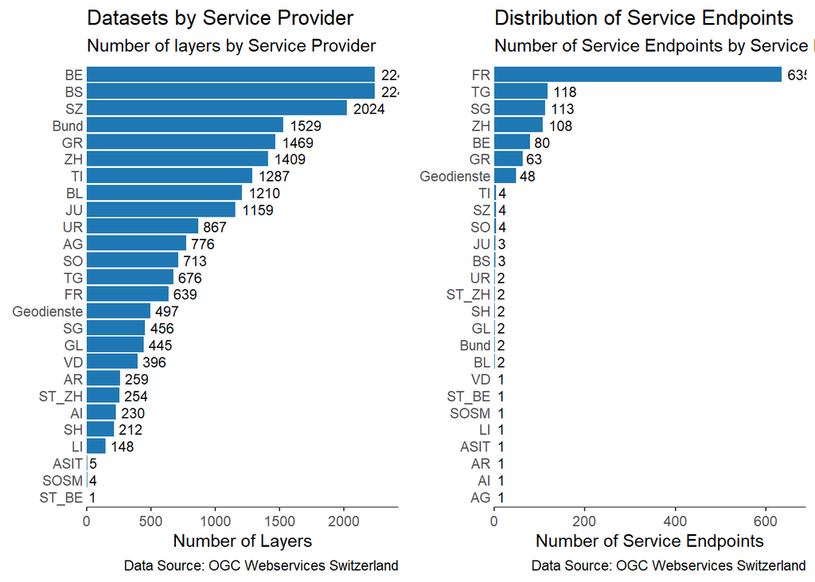

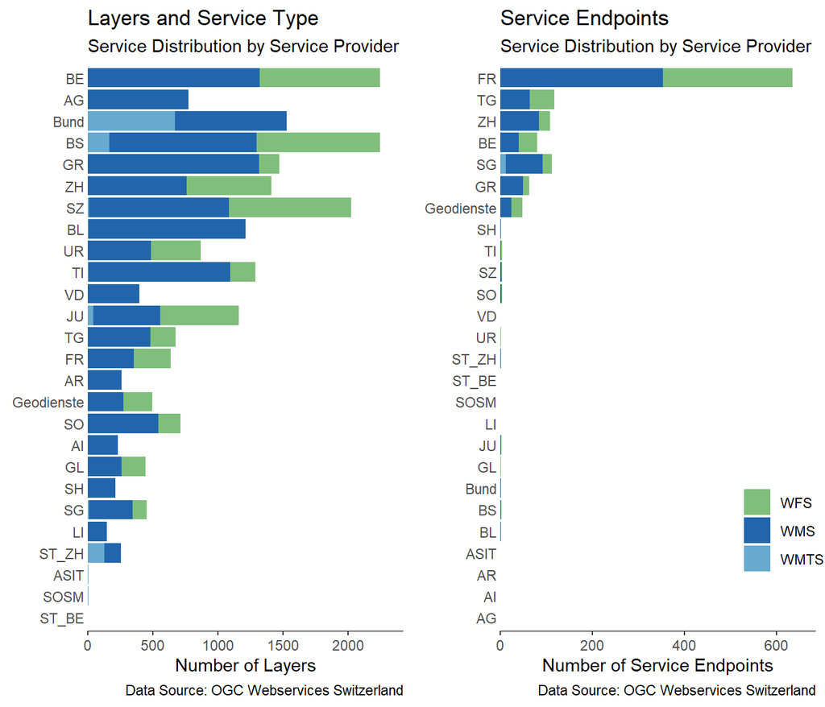

a) Number of Layers provided by each service owner, b) Number of unique service links provided by each service owner

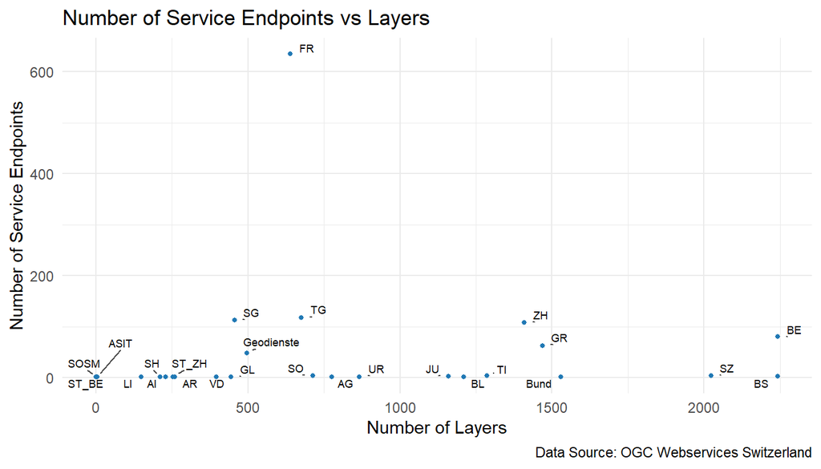

Number of unique service links provided by each service owner

Overview on geoservice provider and services

| provider | layers WMTS | layers WMS | layers WFS | endpoints WMTS | endpoints WMS | endpoints WFS |
| --- | --- | --- | --- | --- | --- | --- |
| BE | 0 | 1319 | 924 | 0 | 40 | 40 |
| GR | 0 | 1315 | 154 | 0 | 50 | 13 |
| BL | 7 | 1203 | 0 | 1 | 1 | 0 |
| BS | 165 | 1130 | 947 | 1 | 1 | 1 |
| TI | 6 | 1089 | 192 | 1 | 1 | 2 |
| SZ | 9 | 1075 | 940 | 1 | 2 | 1 |
| Bund | 671 | 858 | 0 | 1 | 1 | 0 |
| AG | 0 | 776 | 0 | 0 | 1 | 0 |
| ZH | 0 | 760 | 649 | 0 | 85 | 23 |
| SO | 3 | 541 | 169 | 1 | 2 | 1 |
| JU | 42 | 517 | 600 | 1 | 1 | 1 |
| UR | 0 | 488 | 379 | 0 | 1 | 1 |
| TG | 0 | 484 | 192 | 0 | 64 | 54 |
| VD | 0 | 396 | 0 | 0 | 1 | 0 |
| FR | 0 | 356 | 283 | 0 | 354 | 281 |
| SG | 13 | 334 | 109 | 13 | 79 | 21 |
| Geodienste | 0 | 277 | 220 | 0 | 24 | 24 |
| GL | 0 | 260 | 185 | 0 | 1 | 1 |
| AR | 0 | 259 | 0 | 0 | 1 | 0 |
| AI | 0 | 230 | 0 | 0 | 1 | 0 |
| SH | 0 | 212 | 0 | 0 | 2 | 0 |
| LI | 0 | 148 | 0 | 0 | 1 | 0 |
| ST_ZH | 127 | 127 | 0 | 1 | 1 | 0 |
| ASIT | 5 | 0 | 0 | 1 | 0 | 0 |
| SOSM | 4 | 0 | 0 | 1 | 0 | 0 |
| ST_BE | 1 | 0 | 0 | 1 | 0 | 0 |

The following table provides an overview of unique datasets (by title) for each service provider and service offered for each of them. Most of the datasets are uniquely offered as WMS service. This might be good for raster data and and maps, for vector for vector datasets, these should also be offered as a WFS in addition to a WMS or WMTS service. Column WFS with unique WFS layers have likely a WMS or WMTS service with a different title. Canton Fribourg uses for their services with single layers no unique name field and names them *“0”*, hence the service *title* is used for the counts in this table.

Overview of number of geoservice combination by unique layer title

| provider | WMTS | WMS | WMS+WMTS | WFS | WMS+WFS | NA |
| --- | --- | --- | --- | --- | --- | --- |
| KT GR | 0 | 1232 | 0 | 71 | 83 | 0 |
| KT BL | 7 | 1203 | 0 | 0 | 0 | 0 |
| KT TI | 0 | 973 | 6 | 82 | 110 | 0 |
| KT AG | 0 | 776 | 0 | 0 | 0 | 0 |
| KT ZH | 0 | 669 | 0 | 558 | 91 | 0 |
| KT BS | 59 | 540 | 106 | 463 | 484 | 0 |
| KT BE | 0 | 404 | 0 | 9 | 915 | 0 |
| KT SO | 3 | 404 | 0 | 32 | 137 | 0 |
| KT VD | 0 | 396 | 0 | 0 | 0 | 0 |
| KT FR | 0 | 351 | 0 | 278 | 5 | 0 |
| KT TG | 0 | 297 | 0 | 5 | 187 | 0 |
| KT AR | 0 | 259 | 0 | 0 | 0 | 0 |
| Bund | 53 | 240 | 618 | 0 | 0 | 0 |
| KT AI | 0 | 230 | 0 | 0 | 0 | 0 |
| KT SG | 13 | 226 | 0 | 1 | 108 | 0 |
| KT SH | 0 | 212 | 0 | 0 | 0 | 0 |
| FL LI | 0 | 148 | 0 | 0 | 0 | 0 |
| KT SZ | 9 | 138 | 0 | 3 | 937 | 0 |
| KT JU | 2 | 116 | 39 | 238 | 361 | 1 |
| KT UR | 0 | 112 | 0 | 3 | 376 | 0 |
| KT GL | 0 | 79 | 0 | 4 | 181 | 0 |
| Geodienste | 0 | 69 | 0 | 12 | 208 | 0 |
| ASIT | 5 | 0 | 0 | 0 | 0 | 0 |
| SOSM | 4 | 0 | 0 | 0 | 0 | 0 |
| ST BE | 1 | 0 | 0 | 0 | 0 | 0 |
| ST ZH | 0 | 0 | 127 | 0 | 0 | 0 |

The next table shows for each service provider over all service the number of unique names, titles, groups and trees. If the group tag was empty then that layer does not belong to a group and is listed in the *unique title without group* column.

Count of unique occurence for each service provider for usage of titles, names, groups and trees

| provider | total | unique titles | unique names | groups | trees | unique title without groups |
| --- | --- | --- | --- | --- | --- | --- |
| ASIT | 5 | 5 | 5 | 5 | 5 | 0 |
| Bund | 1536 | 911 | 900 | 746 | 1511 | 675 |
| FL_LI | 148 | 148 | 148 | 5 | 32 | 0 |
| Geodienste | 670 | 289 | 486 | 264 | 454 | 0 |
| KT_AG | 941 | 776 | 941 | 374 | 386 | 387 |
| KT_AI | 230 | 230 | 230 | 1 | 1 | 0 |
| KT_AR | 259 | 259 | 259 | 1 | 1 | 0 |
| KT_BE | 2263 | 1328 | 2263 | 928 | 2263 | 1319 |
| KT_BL | 1404 | 1210 | 1404 | 217 | 821 | 0 |
| KT_BS | 2492 | 1652 | 2380 | 1448 | 1556 | 0 |
| KT_FR | 649 | 634 | 287 | 283 | 340 | 356 |
| KT_GL | 445 | 264 | 264 | 204 | 190 | 0 |
| KT_GR | 1898 | 1386 | 1551 | 392 | 1535 | 0 |
| KT_JU | 1299 | 757 | 929 | 703 | 800 | 0 |
| KT_SG | 645 | 348 | 484 | 150 | 645 | 334 |
| KT_SH | 213 | 212 | 213 | 6 | 29 | 16 |
| KT_SO | 734 | 576 | 595 | 264 | 448 | 0 |
| KT_SZ | 2099 | 1087 | 2099 | 1084 | 1843 | 1 |
| KT_TG | 1032 | 489 | 703 | 324 | 436 | 0 |
| KT_TI | 1348 | 1171 | 1227 | 422 | 690 | 0 |
| KT_UR | 878 | 491 | 497 | 452 | 632 | 236 |
| KT_VD | 396 | 396 | 396 | 0 | 396 | 396 |
| KT_ZH | 1926 | 1318 | 1421 | 753 | 845 | 0 |
| SOSM | 4 | 4 | 4 | 4 | 4 | 0 |
| ST_BE | 1 | 1 | 1 | 1 | 1 | 0 |
| ST_ZH | 256 | 127 | 128 | 128 | 256 | 127 |

Not all services are configured in the same way some contain empty invalid name fields such as “0”.

Service Provides where services named as *0*

| provider | nameInvalid |
| --- | --- |
| KT_FR | 351 |

# 2 Metadata

Completeness of metadata description for OGC Web Services in Switzerland

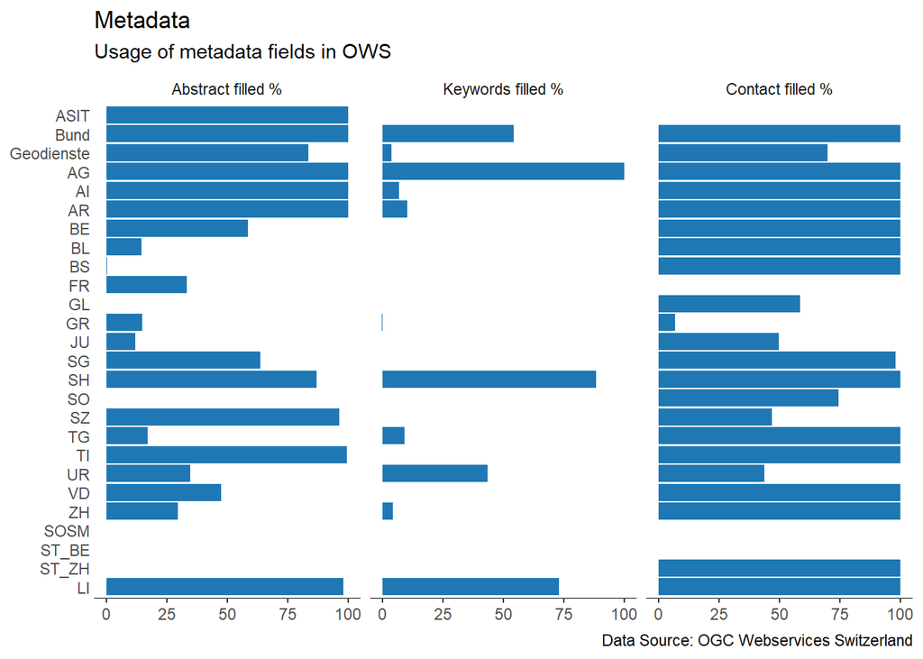

Metadata usage in OGC Web Servics Switzerland, percentage of abstrace, keywords and contact information filled for each data provider

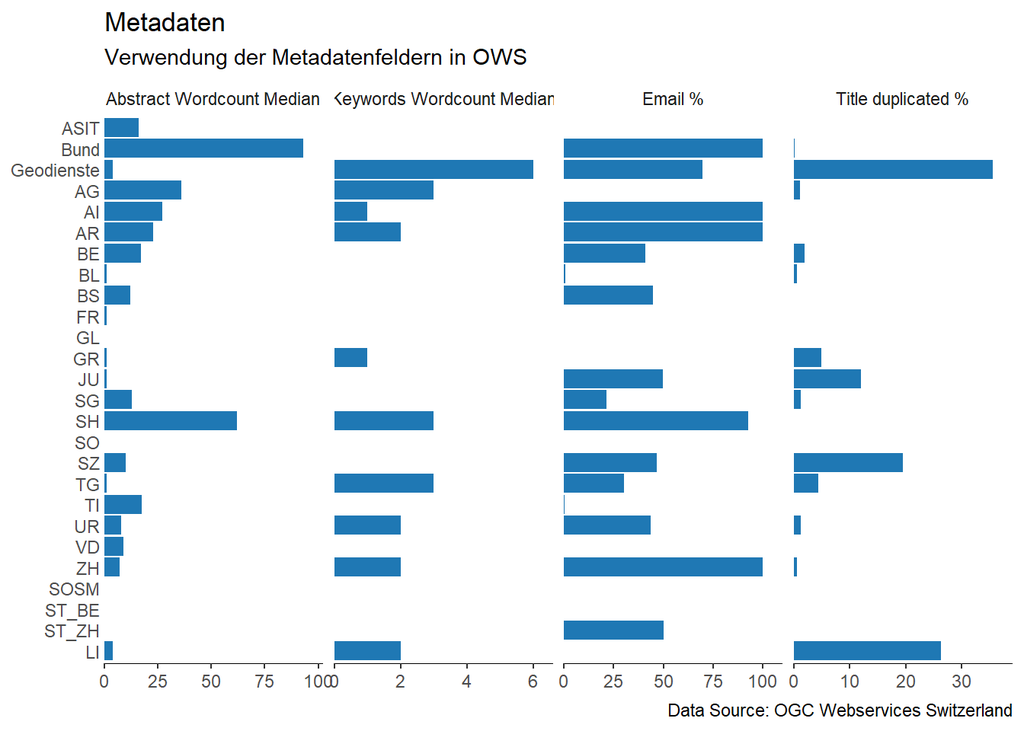

Median Word Count in Abstracts 0, without empty abstracts 14 Median Word Count in Keywords 0, without empty keywords 2

# 3 Spatial Coverage of Geoservices

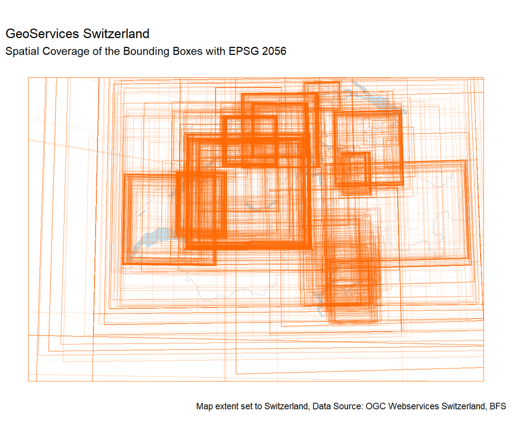

Spatial Coverage of the bounding boxes for all the provided datasets with the map extent set to Switzerland. Extends exceeding these bounds are not depicted.

# 4 Word Clouds

Word clouds generated for OGC Web Services metadata entries title, abstract and keywords. URLs and identifiers are filtered out for better depiction of word usage rather than repetitive urls.

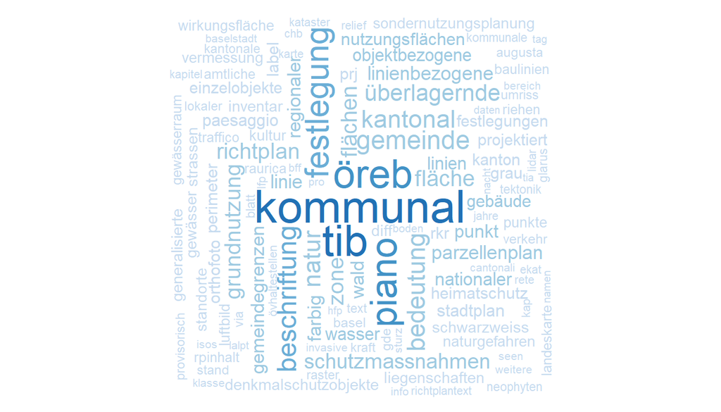

Word Cloud for word frequency of OGC Web Services titles

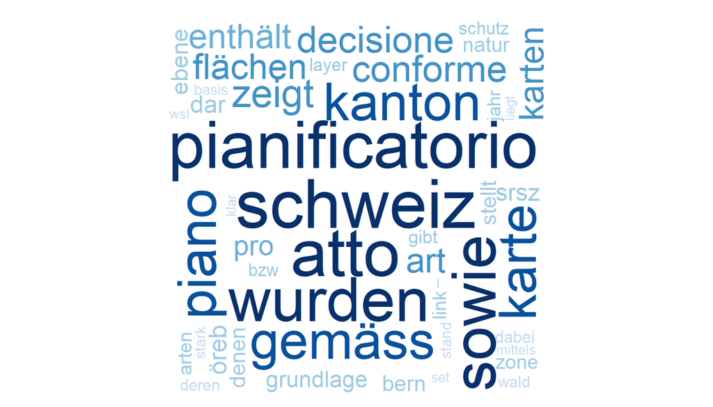

Word Cloud for word frequency of OGC Web Services abstracts

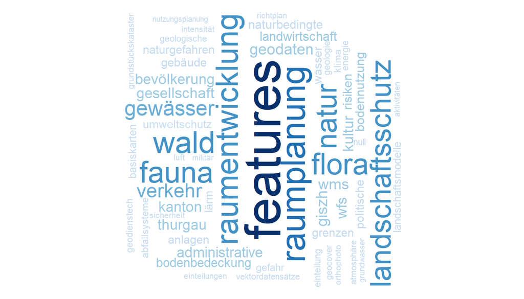

Word Cloud for word frequency of OGC Web Services keywords, omitting urls and identifiers

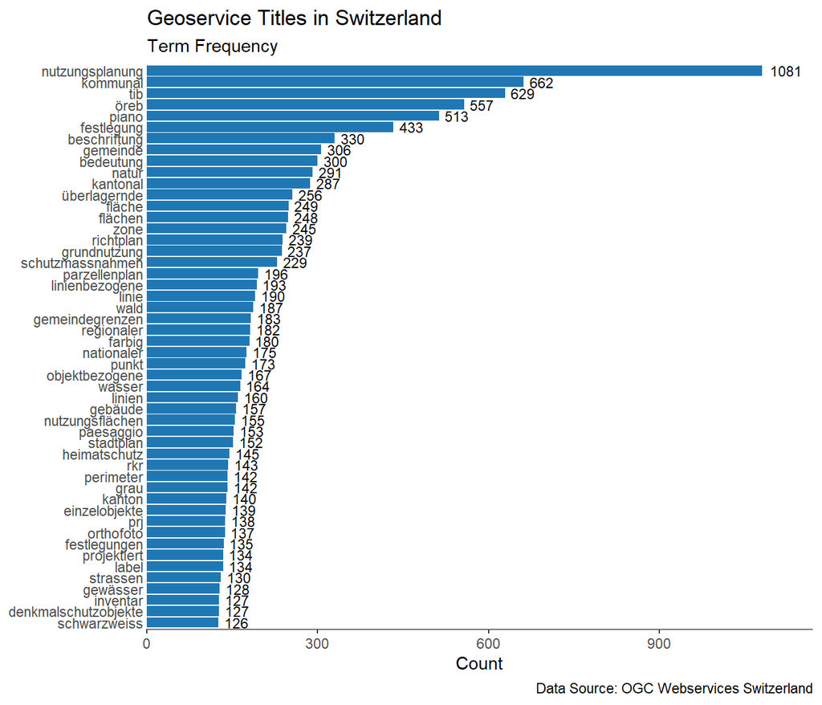

Most frequent Terms for Geoservice title

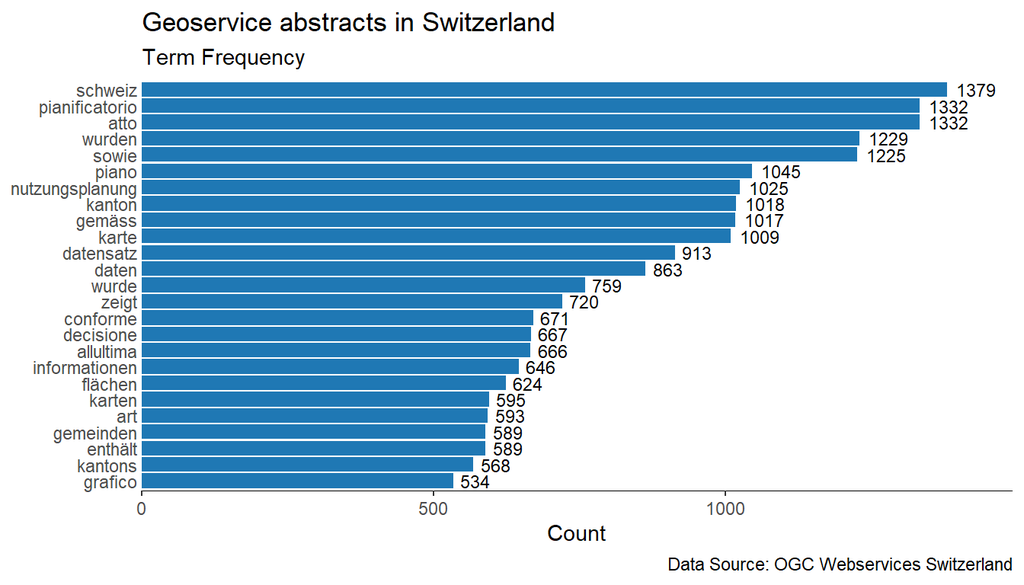

Most frequent Terms for Geoservice abstract

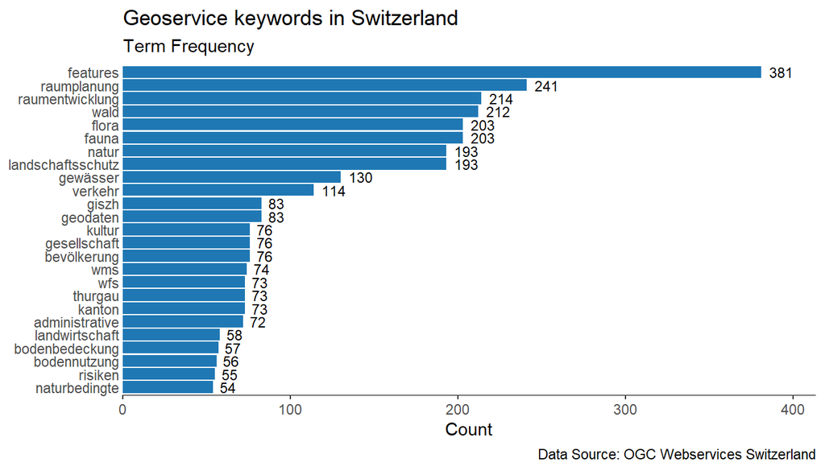

Most frequent Terms for Geoservice keywords